# Ethan’s Iris Analysis in RMarkdown

Ethan Hill

2020-01-20

Hello! Here are the plots and the code for the plots I have generated with the Iris dataset

I’ve scrambled the iris dataset (gotta make it harder) and stored the scrambled data into the object called mix and seperate each column as a vector:

```r
oo <- sample(x=1:150, 150, replace=FALSE)
mix <- iris[oo,]

species <- mix$Species
petalL <- mix$Petal.Length
petalW <- mix$Petal.Width
sepalL <- mix$Sepal.Length
sepalW <- mix$Sepal.Width
```

Now, I can take the species vector and assign each species its own unique color based on logical operations:

```r
species
```

```
##   [1] virginica  versicolor virginica  versicolor versicolor versicolor
##   [7] setosa     virginica  virginica  setosa     virginica  versicolor
##  [13] setosa     virginica  virginica  versicolor setosa     setosa
##  [19] setosa     versicolor virginica  virginica  setosa     setosa
##  [25] virginica  virginica  versicolor versicolor virginica  versicolor
##  [31] virginica  versicolor virginica  versicolor setosa     versicolor
##  [37] setosa     versicolor virginica  setosa     virginica  setosa
##  [43] virginica  versicolor virginica  setosa     versicolor virginica
##  [49] versicolor virginica  virginica  setosa     versicolor versicolor
##  [55] versicolor versicolor versicolor setosa     versicolor setosa
##  [61] setosa     virginica  setosa     versicolor versicolor virginica
##  [67] virginica  setosa     setosa     virginica  setosa     setosa
##  [73] versicolor setosa     setosa     setosa     virginica  setosa
##  [79] setosa     virginica  versicolor versicolor setosa     setosa
##  [85] versicolor versicolor setosa     versicolor setosa     setosa
##  [91] virginica  virginica  versicolor virginica  versicolor virginica
##  [97] versicolor virginica  versicolor setosa     versicolor setosa
## [103] virginica  versicolor setosa     versicolor setosa     setosa
## [109] versicolor setosa     versicolor virginica  virginica  versicolor
## [115] virginica  virginica  versicolor setosa     versicolor setosa
## [121] virginica  setosa     virginica  versicolor setosa     setosa
## [127] virginica  versicolor virginica  virginica  virginica  virginica
## [133] setosa     virginica  versicolor setosa     virginica  setosa
## [139] versicolor virginica  setosa     virginica  virginica  versicolor
## [145] setosa     setosa     versicolor virginica  versicolor setosa
## Levels: setosa versicolor virginica
```

```r
color <- rep("red", 150)
species == "setosa"
```

```
##   [1] FALSE FALSE FALSE FALSE FALSE FALSE  TRUE FALSE FALSE  TRUE FALSE FALSE
##  [13]  TRUE FALSE FALSE FALSE  TRUE  TRUE  TRUE FALSE FALSE FALSE  TRUE  TRUE
##  [25] FALSE FALSE FALSE FALSE FALSE FALSE FALSE FALSE FALSE FALSE  TRUE FALSE
##  [37]  TRUE FALSE FALSE  TRUE FALSE  TRUE FALSE FALSE FALSE  TRUE FALSE FALSE
##  [49] FALSE FALSE FALSE  TRUE FALSE FALSE FALSE FALSE FALSE  TRUE FALSE  TRUE
##  [61]  TRUE FALSE  TRUE FALSE FALSE FALSE FALSE  TRUE  TRUE FALSE  TRUE  TRUE
##  [73] FALSE  TRUE  TRUE  TRUE FALSE  TRUE  TRUE FALSE FALSE FALSE  TRUE  TRUE
##  [85] FALSE FALSE  TRUE FALSE  TRUE  TRUE FALSE FALSE FALSE FALSE FALSE FALSE
##  [97] FALSE FALSE FALSE  TRUE FALSE  TRUE FALSE FALSE  TRUE FALSE  TRUE  TRUE
## [109] FALSE  TRUE FALSE FALSE FALSE FALSE FALSE FALSE FALSE  TRUE FALSE  TRUE
## [121] FALSE  TRUE FALSE FALSE  TRUE  TRUE FALSE FALSE FALSE FALSE FALSE FALSE
## [133]  TRUE FALSE FALSE  TRUE FALSE  TRUE FALSE FALSE  TRUE FALSE FALSE FALSE
## [145]  TRUE  TRUE FALSE FALSE FALSE  TRUE
```

```r
color[species == "setosa"] <- "purple"
color
```

```
##   [1] "red"    "red"    "red"    "red"    "red"    "red"    "purple" "red"
##   [9] "red"    "purple" "red"    "red"    "purple" "red"    "red"    "red"
##  [17] "purple" "purple" "purple" "red"    "red"    "red"    "purple" "purple"
##  [25] "red"    "red"    "red"    "red"    "red"    "red"    "red"    "red"
##  [33] "red"    "red"    "purple" "red"    "purple" "red"    "red"    "purple"
##  [41] "red"    "purple" "red"    "red"    "red"    "purple" "red"    "red"
##  [49] "red"    "red"    "red"    "purple" "red"    "red"    "red"    "red"
##  [57] "red"    "purple" "red"    "purple" "purple" "red"    "purple" "red"
##  [65] "red"    "red"    "red"    "purple" "purple" "red"    "purple" "purple"
##  [73] "red"    "purple" "purple" "purple" "red"    "purple" "purple" "red"
##  [81] "red"    "red"    "purple" "purple" "red"    "red"    "purple" "red"
##  [89] "purple" "purple" "red"    "red"    "red"    "red"    "red"    "red"
##  [97] "red"    "red"    "red"    "purple" "red"    "purple" "red"    "red"
## [105] "purple" "red"    "purple" "purple" "red"    "purple" "red"    "red"
## [113] "red"    "red"    "red"    "red"    "red"    "purple" "red"    "purple"
## [121] "red"    "purple" "red"    "red"    "purple" "purple" "red"    "red"
## [129] "red"    "red"    "red"    "red"    "purple" "red"    "red"    "purple"
## [137] "red"    "purple" "red"    "red"    "purple" "red"    "red"    "red"
## [145] "purple" "purple" "red"    "red"    "red"    "purple"
```

```r
color[species == "versicolor"] <- "blue"
color
```

```
##   [1] "red"    "blue"   "red"    "blue"   "blue"   "blue"   "purple" "red"
##   [9] "red"    "purple" "red"    "blue"   "purple" "red"    "red"    "blue"
##  [17] "purple" "purple" "purple" "blue"   "red"    "red"    "purple" "purple"
##  [25] "red"    "red"    "blue"   "blue"   "red"    "blue"   "red"    "blue"
##  [33] "red"    "blue"   "purple" "blue"   "purple" "blue"   "red"    "purple"
##  [41] "red"    "purple" "red"    "blue"   "red"    "purple" "blue"   "red"
##  [49] "blue"   "red"    "red"    "purple" "blue"   "blue"   "blue"   "blue"
##  [57] "blue"   "purple" "blue"   "purple" "purple" "red"    "purple" "blue"
##  [65] "blue"   "red"    "red"    "purple" "purple" "red"    "purple" "purple"
##  [73] "blue"   "purple" "purple" "purple" "red"    "purple" "purple" "red"
##  [81] "blue"   "blue"   "purple" "purple" "blue"   "blue"   "purple" "blue"
##  [89] "purple" "purple" "red"    "red"    "blue"   "red"    "blue"   "red"
##  [97] "blue"   "red"    "blue"   "purple" "blue"   "purple" "red"    "blue"
## [105] "purple" "blue"   "purple" "purple" "blue"   "purple" "blue"   "red"
## [113] "red"    "blue"   "red"    "red"    "blue"   "purple" "blue"   "purple"
## [121] "red"    "purple" "red"    "blue"   "purple" "purple" "red"    "blue"
## [129] "red"    "red"    "red"    "red"    "purple" "red"    "blue"   "purple"
## [137] "red"    "purple" "blue"   "red"    "purple" "red"    "red"    "blue"
## [145] "purple" "purple" "blue"   "red"    "blue"   "purple"
```

```r
color[species == "virginica"] <- "orange"
color
```

```
##   [1] "orange" "blue"   "orange" "blue"   "blue"   "blue"   "purple" "orange"
##   [9] "orange" "purple" "orange" "blue"   "purple" "orange" "orange" "blue"
##  [17] "purple" "purple" "purple" "blue"   "orange" "orange" "purple" "purple"
##  [25] "orange" "orange" "blue"   "blue"   "orange" "blue"   "orange" "blue"
##  [33] "orange" "blue"   "purple" "blue"   "purple" "blue"   "orange" "purple"
##  [41] "orange" "purple" "orange" "blue"   "orange" "purple" "blue"   "orange"
##  [49] "blue"   "orange" "orange" "purple" "blue"   "blue"   "blue"   "blue"
##  [57] "blue"   "purple" "blue"   "purple" "purple" "orange" "purple" "blue"
##  [65] "blue"   "orange" "orange" "purple" "purple" "orange" "purple" "purple"
##  [73] "blue"   "purple" "purple" "purple" "orange" "purple" "purple" "orange"
##  [81] "blue"   "blue"   "purple" "purple" "blue"   "blue"   "purple" "blue"
##  [89] "purple" "purple" "orange" "orange" "blue"   "orange" "blue"   "orange"
##  [97] "blue"   "orange" "blue"   "purple" "blue"   "purple" "orange" "blue"
## [105] "purple" "blue"   "purple" "purple" "blue"   "purple" "blue"   "orange"
## [113] "orange" "blue"   "orange" "orange" "blue"   "purple" "blue"   "purple"
## [121] "orange" "purple" "orange" "blue"   "purple" "purple" "orange" "blue"
## [129] "orange" "orange" "orange" "orange" "purple" "orange" "blue"   "purple"
## [137] "orange" "purple" "blue"   "orange" "purple" "orange" "orange" "blue"
## [145] "purple" "purple" "blue"   "orange" "blue"   "purple"
```

Cool, Now we can start doing some real analyses. I have have made a best fit line of regression for Sepal Width as a function of Petal Length and have displayed the output stats:

```r
sepalW.lm <- lm(sepalW ~ petalL)
sepalW.lm
```

```
##
## Call:
## lm(formula = sepalW ~ petalL)
##
## Coefficients:
## (Intercept)       petalL
##      3.4549      -0.1058
```

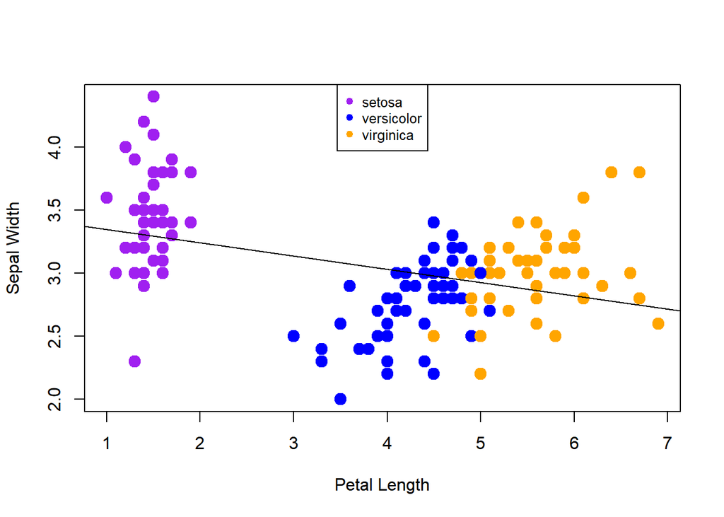

```r
plot(petalL, sepalW, col=color, cex=1.5, pch=19, xlab="Petal Length", ylab="Sepal Width")
abline(sepalW.lm, col="black")
legend('top', legend = levels(species), col = c("purple", "blue", "orange"), cex = .8, pch = 19)
```

As we can see from the graph above, the “general” trend is that as petal length increases, the sepal width decreases.

BUT WAIT THERE’S MORE!!!!

```r
setosa <- mix[species == "setosa",]
setosa
```

```
##    Sepal.Length Sepal.Width Petal.Length Petal.Width Species
## 12          4.8         3.4          1.6         0.2  setosa
## 3           4.7         3.2          1.3         0.2  setosa
## 28          5.2         3.5          1.5         0.2  setosa
## 22          5.1         3.7          1.5         0.4  setosa
## 31          4.8         3.1          1.6         0.2  setosa
## 38          4.9         3.6          1.4         0.1  setosa
## 30          4.7         3.2          1.6         0.2  setosa
## 43          4.4         3.2          1.3         0.2  setosa
## 2           4.9         3.0          1.4         0.2  setosa
## 15          5.8         4.0          1.2         0.2  setosa
## 39          4.4         3.0          1.3         0.2  setosa
## 45          5.1         3.8          1.9         0.4  setosa
## 42          4.5         2.3          1.3         0.3  setosa
## 5           5.0         3.6          1.4         0.2  setosa
```

[output cut: 36 more lines]

```r
setosaPLvsSW.lm <- lm(setosa$Sepal.Width ~ setosa$Petal.Length)
setosaPLvsSW.lm
```

```
##
## Call:
## lm(formula = setosa$Sepal.Width ~ setosa$Petal.Length)
##
## Coefficients:
##         (Intercept)  setosa$Petal.Length
##              2.8609               0.3879
```

```r
versicolor <- mix[species == "versicolor",]
versicolor
```

```
##     Sepal.Length Sepal.Width Petal.Length Petal.Width    Species
## 81           5.5         2.4          3.8         1.1 versicolor
## 64           6.1         2.9          4.7         1.4 versicolor
## 76           6.6         3.0          4.4         1.4 versicolor
## 63           6.0         2.2          4.0         1.0 versicolor
## 57           6.3         3.3          4.7         1.6 versicolor
## 69           6.2         2.2          4.5         1.5 versicolor
## 86           6.0         3.4          4.5         1.6 versicolor
## 88           6.3         2.3          4.4         1.3 versicolor
## 97           5.7         2.9          4.2         1.3 versicolor
## 92           6.1         3.0          4.6         1.4 versicolor
## 58           4.9         2.4          3.3         1.0 versicolor
## 91           5.5         2.6          4.4         1.2 versicolor
## 98           6.2         2.9          4.3         1.3 versicolor
## 82           5.5         2.4          3.7         1.0 versicolor
```

[output cut: 36 more lines]

```r
versicolorPLvsSW.lm <- lm(versicolor$Sepal.Width ~ versicolor$Petal.Length)
versicolorPLvsSW.lm
```

```
##
## Call:
## lm(formula = versicolor$Sepal.Width ~ versicolor$Petal.Length)
##
## Coefficients:
##             (Intercept)  versicolor$Petal.Length
##                  1.1755                   0.3743
```

```r
virginica <- mix[species == "virginica",]
virginica
```

```
##     Sepal.Length Sepal.Width Petal.Length Petal.Width   Species
## 119          7.7         2.6          6.9         2.3 virginica
## 137          6.3         3.4          5.6         2.4 virginica
## 145          6.7         3.3          5.7         2.5 virginica
## 135          6.1         2.6          5.6         1.4 virginica
## 103          7.1         3.0          5.9         2.1 virginica
## 138          6.4         3.1          5.5         1.8 virginica
## 118          7.7         3.8          6.7         2.2 virginica
## 150          5.9         3.0          5.1         1.8 virginica
## 124          6.3         2.7          4.9         1.8 virginica
## 104          6.3         2.9          5.6         1.8 virginica
## 102          5.8         2.7          5.1         1.9 virginica
## 126          7.2         3.2          6.0         1.8 virginica
## 127          6.2         2.8          4.8         1.8 virginica
## 143          5.8         2.7          5.1         1.9 virginica
```

[output cut: 36 more lines]

```r
virginicaPLvsSW.lm <- lm(virginica$Sepal.Width ~ virginica$Petal.Length)
virginicaPLvsSW.lm
```

```
##
## Call:
## lm(formula = virginica$Sepal.Width ~ virginica$Petal.Length)
##
## Coefficients:
##            (Intercept)  virginica$Petal.Length
##                 1.6729                  0.2343
```

THEN WE CAN PLOT THE DATA AGAIN WITH EACH SPECIES HAVING THEIR OWN LINE OF REGRESSION:

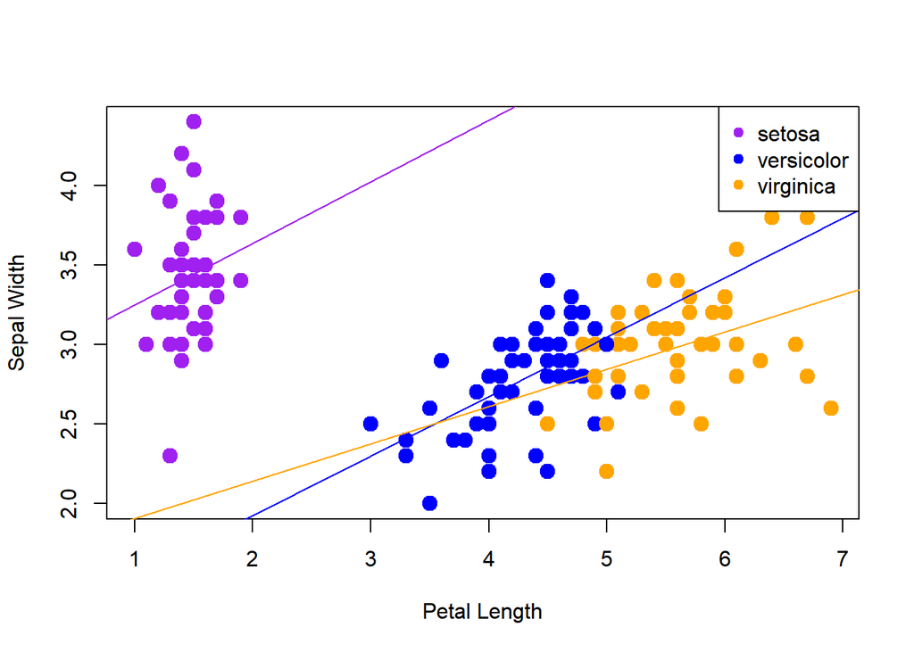

```r
plot(petalL, sepalW, col=color, cex=1.5, pch=19, xlab="Petal Length", ylab="Sepal Width")
abline(setosaPLvsSW.lm, col="purple")
abline(versicolorPLvsSW.lm, col="blue")
abline(virginicaPLvsSW.lm, col="orange")
legend('topright', legend = levels(species), col = c("purple", "blue", "orange"), cex = 1, pch = 19)
```

What we can see from THIS plot is that, within species, as petal length increases, sepal width ALSO increases. WOW, who would have thought.

And this will conclude my simple anaylsis of the iris dataset!